# Project BRFSS Weekly Update

Author

Joshua J. Cook, M.S. DS, M.S. CRM, ACRP-PM, CCRC, Swann A. Adams Ph.D., M.S., FACE

Published

August 11, 2024

## Purpose

Temporal analysis (at least 10 years) of HPV screening/vaccination and cervical cancer diagnosis by sexual orientation and gender identity (SOGI).

- 2014-2023 (2023 not yet available as of 20JUL2024)
- Straight v. non-straight
  - urban v. rural
  - racial/ethnic
- Cis v. trans
  - urban v. rural
  - racial/ethnic

## Temporal Amalgamation

**Warning**

*Switched to SAS Transport Files for Faster / More Efficient Reading.

```r
library(here) # Managing nested directories
library(haven) # Importing SAS XPT files
library(readxl) # Importing Excel files
library(tidyverse) # Data wrangling, viz
library(reshape2) # For restructuring data
library(gt) # For table generation

# Define a function to read, process, and save each SAS file individually to a compressed R RDS file
process_and_save_xpt_files <- function(start_year, end_year, subdirectory, file_extension, temp_directory) {
  for (year in start_year:end_year) {
    # Construct the file path
    file_path <- here(subdirectory, paste0(year, "_data", file_extension))

    # Read the XPT file
    data <- read_xpt(file_path)

    # Ensure consistent data types
    data <- mutate(data, SEQNO = as.character(SEQNO))

    # Save the processed data to a temporary file
    saveRDS(data, file = here(temp_directory, paste0(year, "_data.rds")))
  }
}

# Create a temporary directory to save intermediate files
temp_directory <- "temp_data"
dir.create(temp_directory, showWarnings = FALSE)

# Process and save each XPT file individually
process_and_save_xpt_files(
  start_year = 2014,
  end_year = 2022,
  subdirectory = "Data",
  file_extension = ".XPT",
  temp_directory = temp_directory
)
```

## What’s Missing?

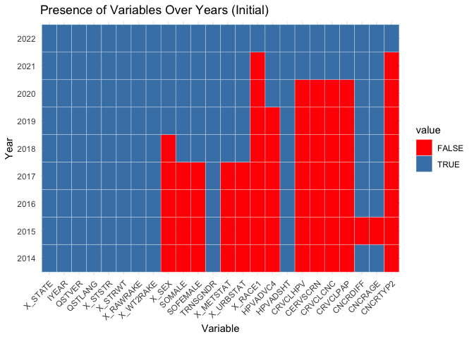

Figure 1

Source: data_missing.qmd

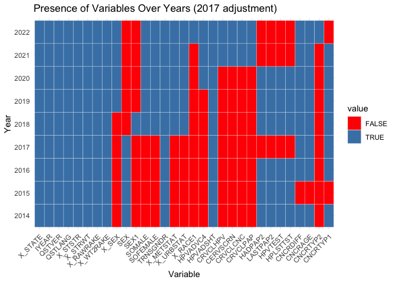

Figure 2

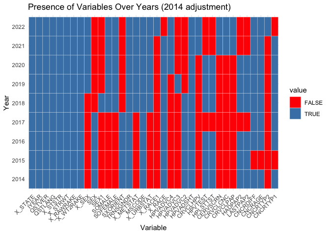

Figure 3

## Codebook / Data Dictionary

```r
library(readxl) # Importing Excel files
library(here) # Managing nested directories
library(tidyverse) # Data wrangling, viz
library(gt) # For table generation

# Construct the path to the codebook using here
codebook_path <- here("Data", "codebook.xlsx")

# Read the Excel file
codes <- read_xlsx(codebook_path, sheet = "Current_Codebook")
```

```r
codes %>%
  gt() %>%
  opt_interactive(
    use_search=TRUE,
    use_filters=TRUE
  )
```

| variable_name | variable_label | variable_type | variable_type_actual | variable_question | variable_section |
| --- | --- | --- | --- | --- | --- |
| _STATE | FIPS Code | Num | Factor | FIPS Code | Record Identification |
| IYEAR | Interview Year | Char | Factor | Interview Year | Record Identification |
| QSTVER | Questionnaire Version Identifier | Num | Factor | Questionnaire Version Identifier | Questionnaire Version |
| QSTLANG | QSTLANG | Num | Factor | Questionnaire Language | Questionnaire Language |
| _STSTR | Sample Design Stratification Variable | Num | Factor | Sample Design Stratification Variable | Weighting Variables |
| _STRWT | Stratum weight | Num | Num | Stratum weight | Weighting Variables |
| _RAWRAKE | Raw weighting factor used in raking | Num | Num | Raw weighting factor used in raking | Weighting Variables |
| _WT2RAKE | Design weight use in raking | Num | Num | Design weight use in raking | Weighting Variables |
| _SEX | Calculated sex variable | Num | Factor | Calculated sex variable | Calculated Variables |
| SEX | Calculated sex variable | Num | Factor | Calculated sex variable | Calculated Variables |

[output cut: 26 more lines]

## Variable Breakdown for Potential Harmonizing

**Warning**

*Need 2023 data release to have 10 years for temporal paper.

### Survey Design, Survey Stratification, Survey Weighting - GOT IT

### Sex - GOT IT (see notes)

- 2022-2019 = X_SEX
- 2018 = SEX_1
- 2017-2014 = SEX

### Sexual Orientation - GOT IT (see notes)

- 2022-2018 = SOMALE (for sex=male), SOFEMALE (for sex=female)
- 2017-2014 = SXORIENT (need to subset by Sex to match SOMALE and SOFEMALE)

### Urban v. Rural - GOT IT (see notes)

- Use MSCODE for all years
- More specifics available for 2022-2018 via X_URBSTAT and X_METSTAT (don’t use?)

### HPV Vaccination - GOT IT (see notes)

- 2022-2020 = HPVADVC4, HPVADSHT
- 2019 = HPVADVC3, HPVADSHT
- 2018-2014 = HPVADVC2, HPVADSHT

### HPV Testing (MAY BE A PART OF PAP TEST) - MISSING 1 YEAR (see notes)

- 2022-2021 = CRVCLHPV
- 2020-2018, 2016-2014 = HPVTEST, HPLSTTST
- 2017 = MISSING

### Cervical Cancer Screening (AKA PAP TEST) - MISSING 1 YEAR (see notes)

- 2022-2021 = CERVSCRN, CRVCLCNC, CRVCLPAP
- 2020-2018, 2016-2014 = HADPAP2, LASTPAP2
- 2017 = MISSING

### Cervical Cancer Diagnosis - MISSING 1 YEAR (see notes)

- 2022 = CNCRDIFF, CNCRAGE, CNCRTYP2
- 2021-2016, 2014 = CNCRDIFF, CNCRAGE, CNCRTYP1
- 2015 = MISSING

## Summary

To complete a temporal analysis as planned, we need to wait for 2023 data. In the meantime, we can begin **cleaning and analyzing 2022-2014 data as noted above.**

We have complete and clean data for the following:

- survey design,
- survey stratification,
- survey weighting,
- gender identity.

We can engineer complete and clean data for:

- sex,
- sexual orientation,
- urban v. rural status,
- HPV vaccination.

We will have incomplete but clean data (missing 1 year each) for:

- HPV testing,
- cervical cancer screening,
- cervical cancer diagnoses.

These findings impact our timelines for the abstract and manuscript submissions, but do not impact our technical papers (which are due in the coming weeks).